# PCA and MDS (Assignment 2)

Sofia Nightingale, Ferran Estrella, Alessandro Valls

2026-02-27

The file PopPyrISO.Rdata contains the 2020 population pyramids of 189 countries and geographical regions in the world (computed using data downloaded from United Nations, Population Division). The following sentence read these data (in the data frame PopPyrISO):

```r
load("PopPyrISO.Rdata")
```

The data frame PopPyrISO has five first columns with the ISO numeric code, English and French names, and alphanumeric ISO codes of length 2 and 3 for each country, then 21 columns for proportions of male population in different age intervals, then 21 more for females, and a last column with the total population of each country.

The following sentences define the function plot.PopPyrISO and use it to plot 6 randomly selected population pyramids (green for male, blue for female):

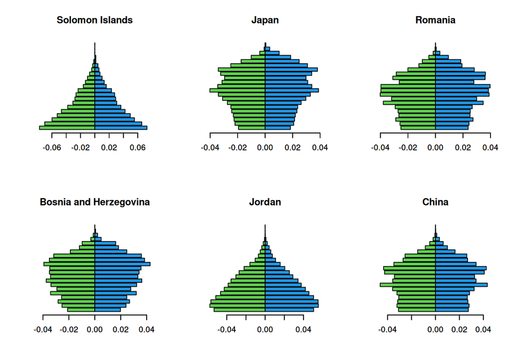

```r
library(graphics)
plot.PopPyrISO <- function(Prop.M.F, label=NULL, col=NULL,
                           col.Male=col, col.Female=col){
  Prop.M.F <- as.numeric(Prop.M.F)
  n.ages <- length(Prop.M.F)/2
  barplot(-Prop.M.F[1:n.ages], horiz = TRUE,
          main=label, col=col.Male,
          #xlab="   Male  -  Female",
          xlim=c(-1,1)*max(Prop.M.F))
  barplot(Prop.M.F[n.ages+(1:n.ages)], horiz = TRUE,
          col=col.Female, add=TRUE)
}

n <- dim(PopPyrISO)[1]
op <- par(mfrow=c(2,3))
for (j in sample(n,6))
   plot.PopPyrISO(PopPyrISO[j,6:47],PopPyrISO$English.short.name[j],col.Male=3, col.Female=4)
```

```r
par(op)
```

## 1. Principal Component Analysis (PCA)

Let us consider the columns of the data frame PopPyrISO[,6:47], which contain the population pyramids values. We store this data in a $n \times p$ data matrix $X$:

```r
X<-PopPyrISO[,6:47]
```

We want to perform the PCA on $X$. Recall that the data matrix of sample principal components (PCs) of $X$ is
$$\mathbf{Y}=(\mathbf{y_1},\dots,
\mathbf{y_p})=(\mathbf{X}-\mathbf{1}_n\mathbf{m'})V$$
where $\mathbf{y_i}$ is the $i$th PC, $\mathbf{1}_n$ is the vector with all 1’s, $\mathbf{m}$ is the mean vector of $X$, ’ denotes the transpose, and $V$ is the orthonormal matrix whose columns are the eigenvectors $v_1,\dots,v_p \in \mathbb{R}^n$ of the sample covariance matrix:

$$\mathbf{S}=\frac{1}{n-1}(\mathbf{X}-\mathbf{1}_n\mathbf{m'})'(\mathbf{X}-\mathbf{1}_n\mathbf{m'}).$$
The eigenvectors in $\mathbf{V}$ are ordered in non-increasing order according to the eigenvalues of $S$.

Additionally, the sample mean of each $k$th PC is zero, and its sample variance is equal to the corresponding eigenvalue $\lambda_k$ of the sample covariance matrix:

$$\text{var}(\mathbf{y_k})=\lambda_k.$$

### 1.a PCA and Biplot

In R, we can use the function princomp from the stats library to compute the PCs, which is based on the eigendecomposition of $\mathbf{S}$ (as explained). It also computes the variance of each PC, the proportion of variance explained (obtained by dividing by the total variance $\mathrm{Tr}(\mathbf{S})$), and the cumulative proportion of variance explained along the different PC directions:

```r
library(stats)
PCA <- princomp(X)
summary(PCA)
```

```
## Importance of components:
##                            Comp.1     Comp.2      Comp.3      Comp.4
## Standard deviation     0.05620761 0.01381843 0.009024605 0.006144128
## Proportion of Variance 0.87475356 0.05287041 0.022550277 0.010452398
## Cumulative Proportion  0.87475356 0.92762398 0.950174253 0.960626651
##                             Comp.5      Comp.6      Comp.7      Comp.8
## Standard deviation     0.005939017 0.004720625 0.003753965 0.003693017
## Proportion of Variance 0.009766177 0.006170133 0.003901897 0.003776226
## Cumulative Proportion  0.970392828 0.976562961 0.980464858 0.984241084
##                             Comp.9     Comp.10     Comp.11     Comp.12
## Standard deviation     0.003126317 0.002650595 0.002295811 0.002206542
## Proportion of Variance 0.002706210 0.001945281 0.001459378 0.001348093
## Cumulative Proportion  0.986947295 0.988892576 0.990351953 0.991700046
##                            Comp.13      Comp.14      Comp.15      Comp.16
## Standard deviation     0.001924762 0.0018280896 0.0017903738 0.0017004696
## Proportion of Variance 0.001025769 0.0009253167 0.0008875297 0.0008006325
## Cumulative Proportion  0.992725815 0.9936511321 0.9945386618 0.9953392942
##                             Comp.17      Comp.18      Comp.19      Comp.20
## Standard deviation     0.0016007686 0.0014735280 0.0014230773 0.0013173818
## Proportion of Variance 0.0007095003 0.0006011907 0.0005607283 0.0004805281
## Cumulative Proportion  0.9960487946 0.9966499853 0.9972107135 0.9976912416
##                             Comp.21     Comp.22      Comp.23      Comp.24
## Standard deviation     0.0011545675 0.001130618 0.0010642269 0.0008319810
## Proportion of Variance 0.0003690916 0.000353938 0.0003135913 0.0001916559
## Cumulative Proportion  0.9980603332 0.998414271 0.9987278625 0.9989195184
##                             Comp.25      Comp.26      Comp.27      Comp.28
## Standard deviation     0.0007853109 0.0007234252 0.0006997459 0.0006745873
## Proportion of Variance 0.0001707571 0.0001449048 0.0001355739 0.0001260004
## Cumulative Proportion  0.9990902755 0.9992351803 0.9993707542 0.9994967546
##                             Comp.29      Comp.30      Comp.31      Comp.32
## Standard deviation     0.0006292044 5.606162e-04 5.290063e-04 4.971104e-04
## Proportion of Variance 0.0001096173 8.702155e-05 7.748492e-05 6.842286e-05
## Cumulative Proportion  0.9996063718 9.996934e-01 9.997709e-01 9.998393e-01
##                             Comp.33      Comp.34      Comp.35      Comp.36
## Standard deviation     3.963896e-04 3.739908e-04 3.302799e-04 2.697854e-04
## Proportion of Variance 4.350508e-05 3.872731e-05 3.020368e-05 2.015266e-05
## Cumulative Proportion  9.998828e-01 9.999215e-01 9.999517e-01 9.999719e-01
##                             Comp.37      Comp.38      Comp.39      Comp.40
## Standard deviation     2.464278e-04 1.821059e-04 7.702423e-05 3.897645e-05
## Proportion of Variance 1.681415e-05 9.182133e-06 1.642670e-06 4.206299e-07
## Cumulative Proportion  9.999887e-01 9.999979e-01 9.999995e-01 9.999999e-01
##                             Comp.41      Comp.42
## Standard deviation     1.351032e-05 1.431994e-10
## Proportion of Variance 5.053903e-08 5.677772e-18
## Cumulative Proportion  1.000000e+00 1.000000e+00
```

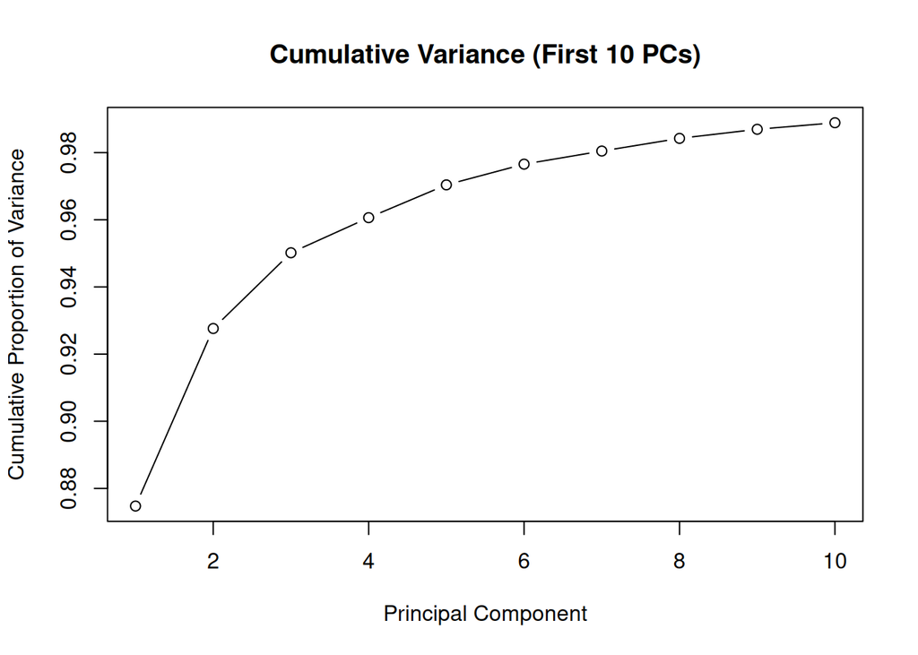

```r
eigvals <- PCA$sdev^2
prop_var <- eigvals/sum(eigvals)
cum_var <- cumsum(prop_var)

plot(cum_var[1:10], type = "b", xlab = "Principal Component",ylab = "Cumulative Proportion of Variance",main = "Cumulative Variance (First 10 PCs)")
```

We can also obtain the biplot of the performed PCA. The biplot is a two-dimensional graphical representation involving two different classes of objects.

1. On the one hand, the biplot displays the first two scores, $y_{i1}$ and $y_{i2}$, of each data observation $\mathbf{x}_i$, $i=1,\dots,n$. Recall that the score of observation $i$ on the $j$th PC, $y_{ij}$, is the projection of the centered observation $\mathbf{x}_i-\mathbf{m}$ onto the $j$th PC, that is, onto the direction $\mathbf{v}_j$.

The first two scores of each data observation are plotted as black dots in the biplot.

2. On the other hand, the biplot displays the first two loadings, $V_{i1}=(v_1)_i$ and $V_{i2}=(v_2)_i$, of each of the original variables, $i=1,\dots,p$. Recall that the loading of variable $i$ on the $j$th PC, $V_{ij}=(v_j)_i$, is the projection of the canonical basis vector $\mathbf{e}_i$ onto the $j$th PC, that is, onto the direction $\mathbf{v}_j$.

Additionally, in the biplot, the projection of the $i$th variable onto the first two PCs is scaled in each component by the corresponding standard deviations, yielding the coordinates $(\sqrt{\lambda_1}\, (v_1)_i, \sqrt{\lambda_2}\, (v_2)_i)$. This scaling is used by default in the biplot function in R (and is known as Gabriel’s symmetric scaling).

The first two loadings of each variable are represented as red arrows in the plane.

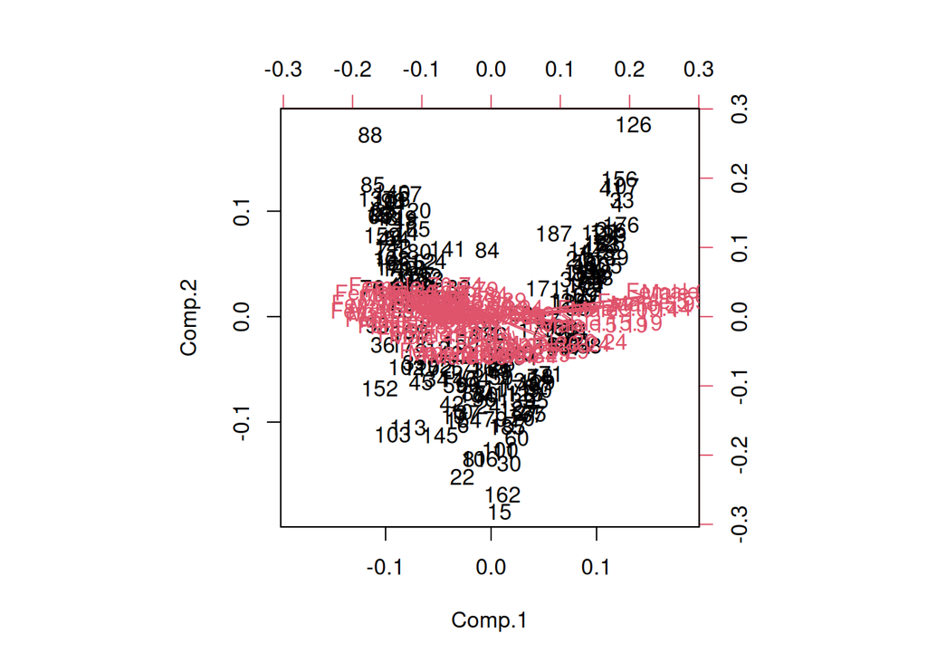

```r
biplot(PCA)
```

We observe the loadings orientated towards the first PC, as expected, since it accumulates almost 88% of the sample variance. Also, the projection of the data sample in the first and second PC plane has a ‘V’ shape.

### 1.b Scatterplots

Let us now obtain the scatterplots of the PC scores:

(PC1, PC2), (PC1, PC3), (PC1, PC4),

labeling the points with country names (the alphanumeric ISO codes of length 3, for clarity).

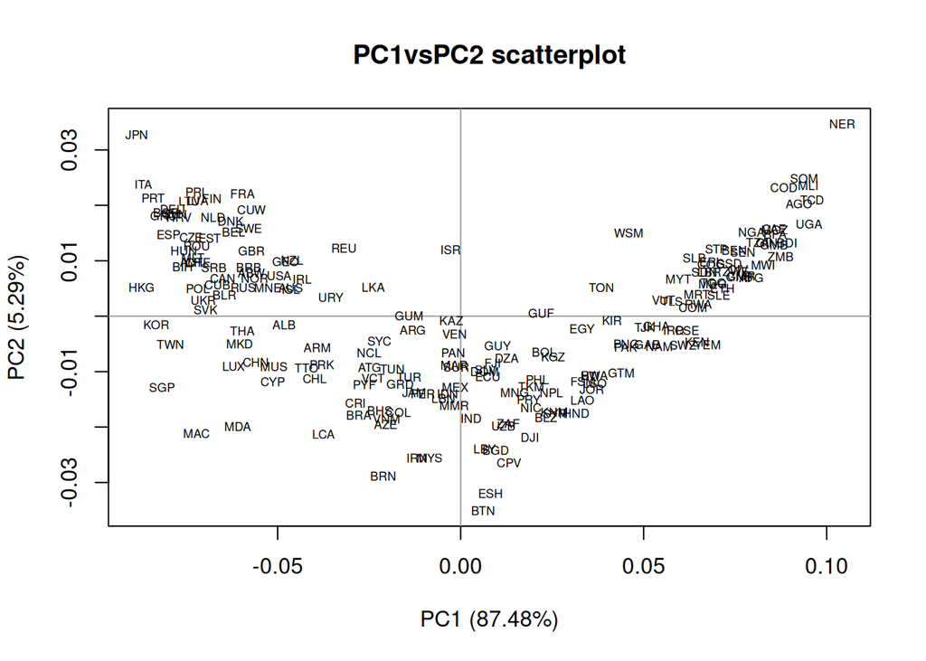

```r
plot(PCA$scores[,c(1,2)], type = "n",
     xlab = paste("PC1 (", round(100*PCA$sdev[1]^2 / sum(PCA$sdev^2), 2), "%)", sep=""),
     ylab = paste("PC2 (", round(100*PCA$sdev[2]^2 / sum(PCA$sdev^2), 2), "%)", sep=""))
abline(v=0, h=0, col=8)

text(PCA$scores[,1], PCA$scores[,2], labels = PopPyrISO$Alpha.3.code, cex = 0.55)
title("PC1vsPC2 scatterplot")
```

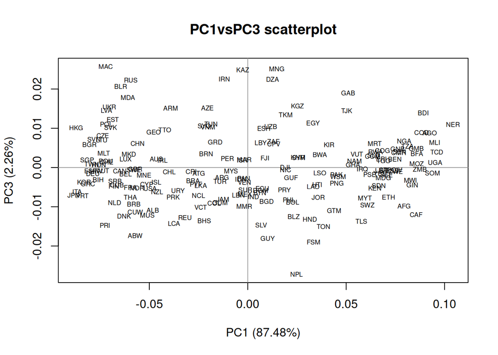

```r
plot(PCA$scores[,c(1,3)], type = "n",
     xlab = paste("PC1 (", round(100*PCA$sdev[1]^2 / sum(PCA$sdev^2), 2), "%)", sep=""),
     ylab = paste("PC3 (", round(100*PCA$sdev[3]^2 / sum(PCA$sdev^2), 2), "%)", sep=""))
abline(v=0, h=0, col=8)

text(PCA$scores[,1], PCA$scores[,3], labels = PopPyrISO$Alpha.3.code, cex = 0.55)
title("PC1vsPC3 scatterplot")
```

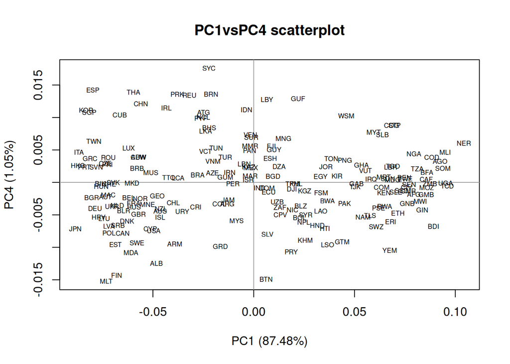

```r
plot(PCA$scores[,c(1,4)], type = "n",
     xlab = paste("PC1 (", round(100*PCA$sdev[1]^2 / sum(PCA$sdev^2), 2), "%)", sep=""),
     ylab = paste("PC4 (", round(100*PCA$sdev[4]^2 / sum(PCA$sdev^2), 2), "%)", sep=""))
abline(v=0, h=0, col=8)

text(PCA$scores[,1], PCA$scores[,4], labels = PopPyrISO$Alpha.3.code, cex = 0.55)
title("PC1vsPC4 scatterplot")
```

The PCs are uncorrelated by construction, and the directional eigenvectors are linearly independent. Additionally, if we look at the scatterplot of PC1 versus PC2, we observe that the scores are distributed in a ‘V’ shape resembling a parabola. This indicates that PC1 and PC2 are not statistically independent, since there is a non-linear (quadratic) relationship between them in the data.

While linear dimensionality reduction techniques cannot capture this quadratic structure in a single direction, non-linear dimensionality reduction methods could potentially map the data onto a one-dimensional quadratic curve.

### 1.c Loadings

Let us now represent the loadings of the first four PCs as population pyramids, using the function plot.PopPyrISO. We recall that since PCA$loadings is the matrix V, then the loadings of the first four PCs are the first four columns:

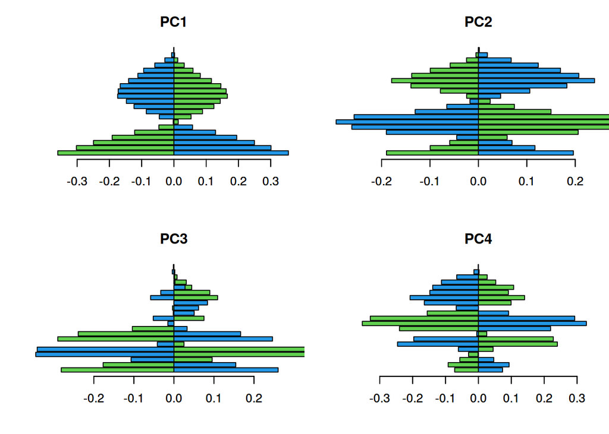

```r
loadings4PC<-PCA$loadings[,1:4]
op <- par(mfrow=c(2,2), mar=c(4,4,3,1))
plot.PopPyrISO(loadings4PC[,1], col.Male=3, col.Female=4)
title("PC1")
plot.PopPyrISO(loadings4PC[,2], col.Male=3, col.Female=4)
title("PC2")
plot.PopPyrISO(loadings4PC[,3], col.Male=3, col.Female=4)
title("PC3")
plot.PopPyrISO(loadings4PC[,4], col.Male=3, col.Female=4)
title("PC4")
```

```r
par(op)
```

We observe that, since the loadings for the first four PCs are components of eigenvectors, they can take negative values. This was not the case when representing the original data, which was positive. As a result, our convention of plotting male data as negative and female data as positive does not work as intended. This explains why some male bars (green) appear positive and some female bars (blue) appear negative in these plots.

### 1.d Mean Population Pyramid variation along PCs

Now, we study how the mean population pyramid changes when moving along the first four principal components. This can be visualized by plotting the graphics mean±cte.j*PC.j for j=1,2,3,4, and cte.j is a chosen scaling constant (e.g., the 0.9 quantile of the absolute scores of principal component j). These plots show the effect of each principal component on the average population structure:

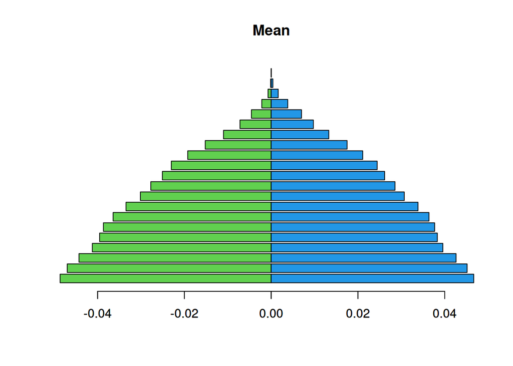

```r
mean=colMeans(X)
plot.PopPyrISO(mean, label=paste("Mean"), col.Male=3, col.Female=4)
```

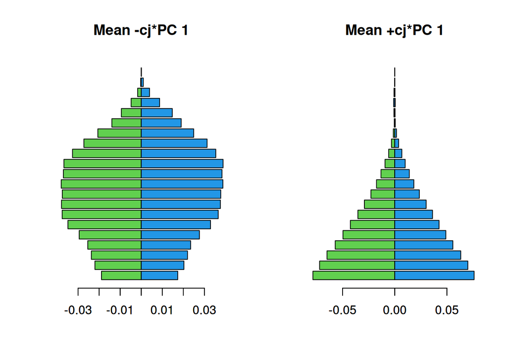

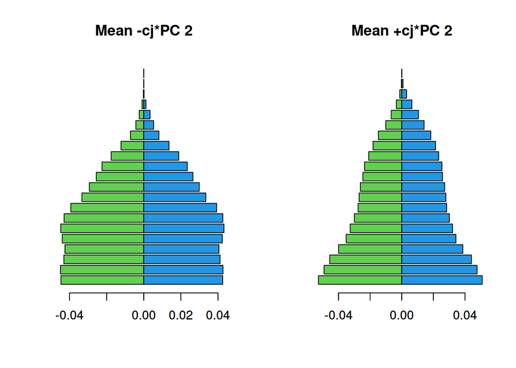

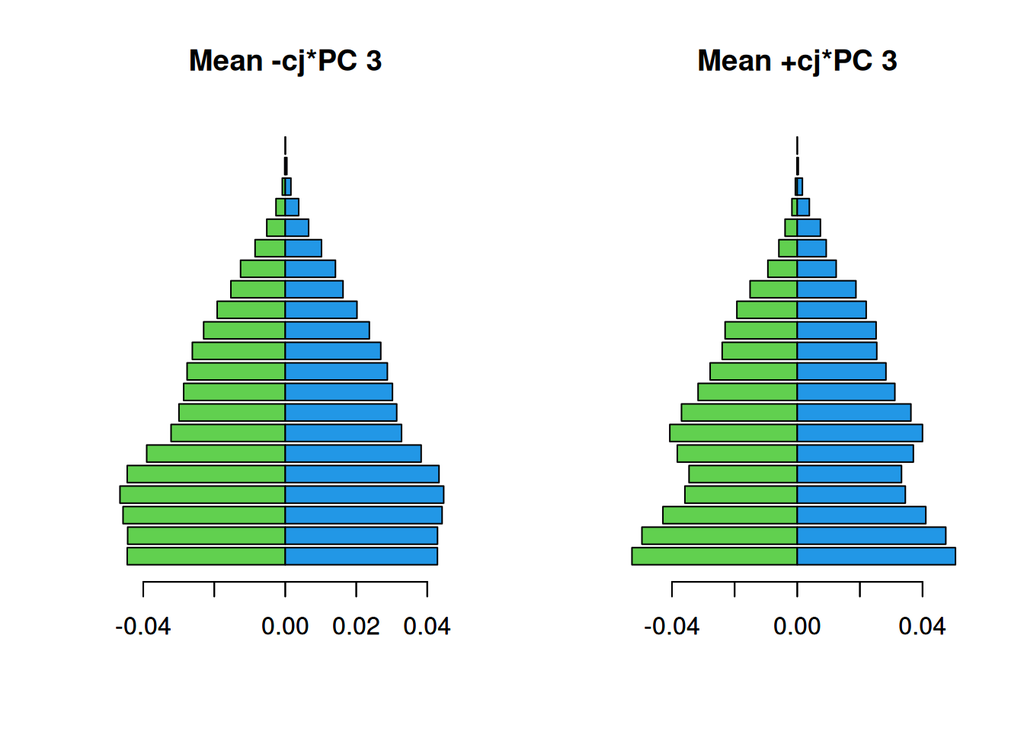

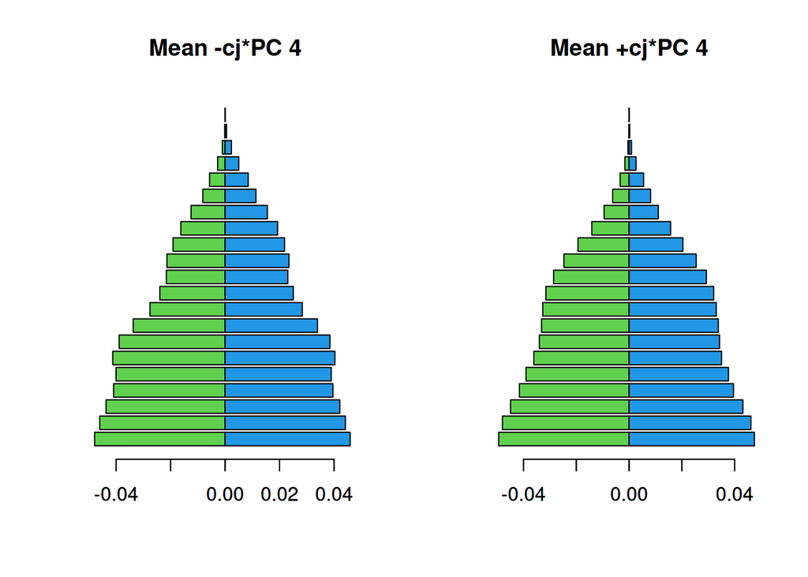

```r
op <- par(mfrow=c(1,2))
for (j in 1:4){
  c_j <- quantile(abs(PCA$scores[,j]), 0.9)
  plot.PopPyrISO(mean-c_j*loadings4PC[,j], label=paste("Mean -cj*PC",j), col.Male=3, col.Female=4)
  plot.PopPyrISO(mean+c_j*loadings4PC[,j], label=paste("Mean +cj*PC",j), col.Male=3, col.Female=4)
}
```

```r
par(op)
```

### 1.e Interpretation

Let us interpret the results we obtained in the previous plots:

-For the first principal component, we observe from the plot in 1.c that the components have larger absolute values for younger ages (approximately 0–20) and for older ages (approximately 40–60). Moreover, the signs of the components for these two age groups are opposite.

This means that PC1 changes the relative weight of the young and older age groups compared to the rest of the population. This effect can be observed when moving along this direction and modifying the average population structure, as shown in the plot from 1.d. Specifically, the plot shows that when we move in one direction, more weight is assigned to the older ages (−cj), whereas when we move in the opposite direction, more weight is assigned to the younger ages (+cj).

Demographically, countries differ mainly in 2 groups: the young, fast-growing populations (wide base, e.g. Kenya) which we will refer to as young populations, and the aging populations (large elderly share, e.g. Japan) which we will refer to as old populations. The PC1 can be interpreted as this main demographic development/aging axis.

-For the second principal component, we observe from the plot in 1.c that the components have the largest absolute values for the adult ages (approximately 25–35), while the components for the very young (approximately 0–10) and very old ages (approximately 55–65) are somewhat smaller but still substantial. Moreover, the signs of the components for the adult ages are opposite to those of the young and old ages, which share the same sign.

This means that PC2 changes the relative weight of the adult age group compared to the rest of the population, while the young and older age groups are affected approximately equally. This effect is illustrated in plot 1.d, where we see that moving along PC2 changes the weight assigned to the adult ages: more weight when moving in the −cj direction, and less weight when moving in the +cj direction.

Therefore, PC2 can be interpreted as a shape variation within the working-age population, often reflecting migration effects or “baby booms.”

*Notably, we observe that the PC1 and PC2 directions are (approximately) symmetric with respect to gender. This indicates that variation along these directions primarily reflects age structure, while gender differences are captured by the remaining principal components, which may exhibit some asymmetries—for instance, PC3 and PC4 in the older age groups.

### 1.f Data Dimensionality Reduction

Now, we compute the approximation of an observation as a linear combination of $k$ PCs: $\mathbf{x_i^{(k)}} = \mathbf{m} + \sum_{j=1}^{k} y_{ij} \mathbf{v_j}$.

Since PCA.scores[i,1:k]=$(y_{i1},\dots,y_{ik})$ is a row vector, to compute the sum we just need to multiply it by the left to V’[1:k,], which is the transpose of V=PCA.loadings[,1:k].

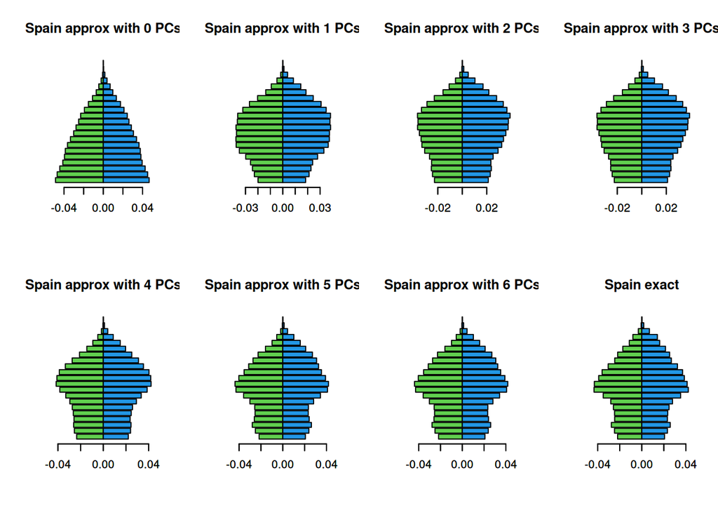

```r
i=which(PopPyrISO$English.short.name=="Spain")

op <- par(mfrow=c(2,4))

for (k in 0:6) {
  approx <- mean
  if (k > 0) {
    approx <- approx+as.numeric(PCA$scores[i,1:k] %*% t(as.matrix(PCA$loadings[,1:k])))
  }
  plot.PopPyrISO(approx,
                 label=paste("Spain", "approx with", k, "PCs"),
                 col.Male=3, col.Female=4)
}
plot.PopPyrISO(X[i,], label=paste("Spain exact"), col.Male=3, col.Female=4)
```

```r
par(op)
```

## 2. Multidimensional scaling

We first compute the symmetrized Kullback-Leibler divergence as a distance between two population pyramids $x$ and $y$.

```r
require(flexmix)
aux <- flexmix::KLdiv(t(PopPyrISO[,6:47]),method="discrete")
d.KL <- as.dist((aux+t(aux))/2)
```

### 2a. Metric MDS

We perform a classical metric MDS of the data, using the cmdscale program and plot all the eigenvalues below.

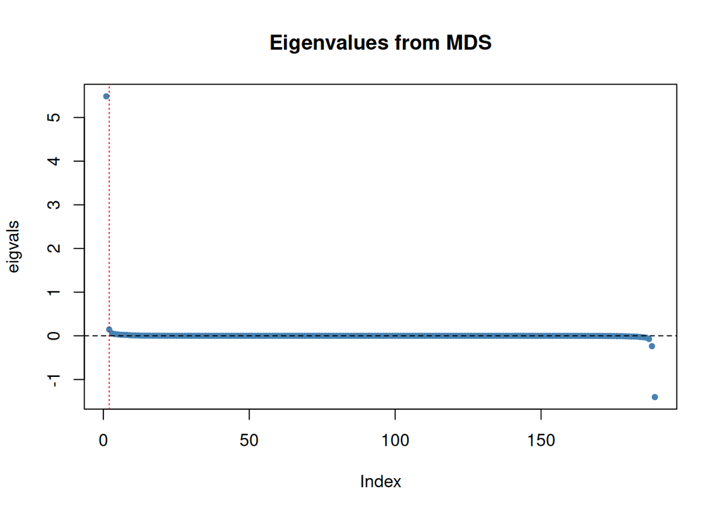

```r
out <- cmdscale(d.KL, k = 2, eig = TRUE)
eigvals <- out$eig

plot(eigvals, main="Eigenvalues from MDS", pch=20, col="steelblue")
abline(h = 0, col = "black", lty = 2)
abline(v = 2, col = "red", lty = 3)
```

The eigenvalue plot reveals that the first eigenvalue captures a large majority of the variance. By plotting the percentage of variance for the first ten eigenvalues, we see that the first eigenvalue is indeed dominant, accounting for over 90% of the total variance.

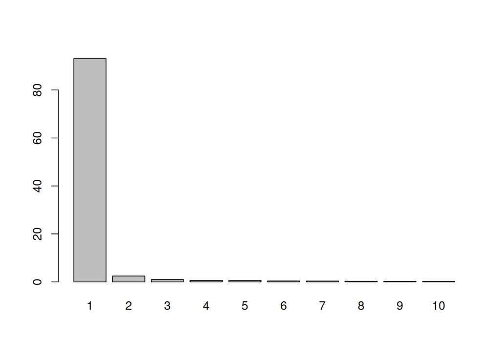

```r
# plotting the percentage of variance for each eigenvalue
perc_var <- pmax(eigvals,0) / sum(pmax(eigvals,0)) * 100
barplot(perc_var[1:10], names.arg=1:10)
```

```r
print(out$GOF)
```

```
## [1] 0.7154375 0.9554587
```

With dimension $k=2$ we obtain
$$GOF ≈ (0.715, 0.955).$$
The 2D solution captures most of the Euclidean component of the dissimilarities. The lower value of $g_1$ is expected, as it reflects the non-Euclidean nature of KL divergence.

### 2b. Goodness of fit

To calculate the goodness-of-fit of the solution we calculate the cumulative sum of the first $k$ eigenvalues and divide it by the total sum of all eigenvalues.

```r
cumsum(eigvals[1:2])/sum(abs(eigvals))*100
```

```
## [1] 69.70880 71.54375
```

```r
cumsum(eigvals[1:2])/sum(pmax(eigvals,0))*100
```

```
## [1] 93.09531 95.54587
```

For $k=2$, the GOF is approximately 71.5% when considering $\sum |\lambda_j|$ (which penalizes negative eigenvalues), and approximately 95.5% when considering only positive eigenvalues. We can therefore conclude that the 2D solution captures most of the Euclidean part of the dissimilarities and provides a good low-dimensional representation, although some distortion remains due to non-Euclidean components (negative eigenvalues).

### 2c. The scatterplot

We represent the dissimilarities by plotting the data corresponding to the first two dimensions using the 3-codes as labels (we do not use full names for clarity):

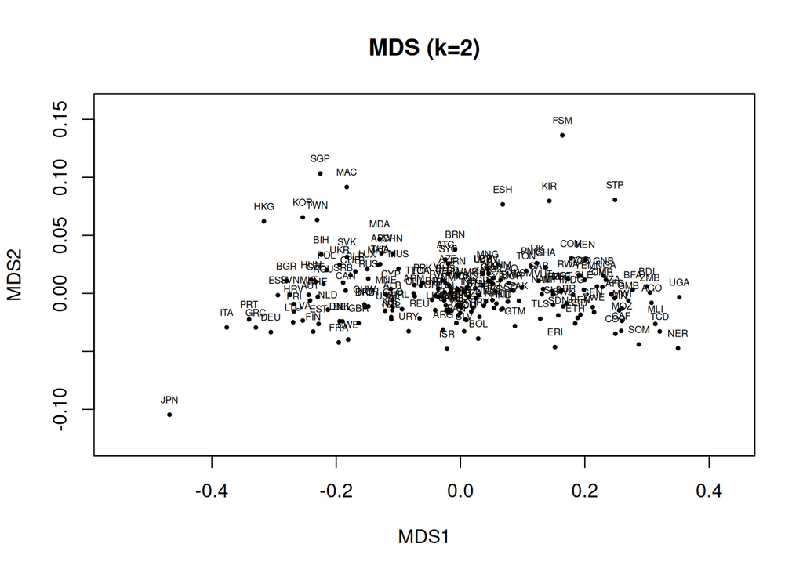

```r
X <- out$points

rx <- range(X[,1]); ry <- range(X[,2])
padx <- 0.10 * diff(rx)
pady <- 0.10 * diff(ry)

plot(X[,1], X[,2], pch=19, cex=0.4,
     xlab="MDS1", ylab="MDS2",
     main="MDS (k=2)",
     xlim = c(rx[1]-padx, rx[2]+padx),
     ylim = c(ry[1]-pady, ry[2]+pady))

par(xpd = NA)
text(X[,1], X[,2], labels=PopPyrISO$Alpha.3.code, pos=3,cex=0.5)
```

```r
par(xpd = FALSE)
```

### 2d. Interpreting the scatterplot

To interpret the meaning of the first two dimensions, we plot the population pyramids of countries at the $0.1, 0.5$ and $0.9$ quantile. For dimension $1$:

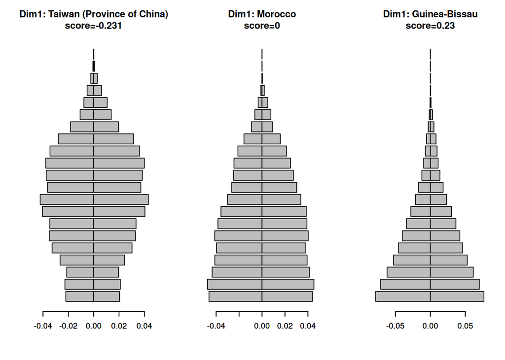

```r
# returns index of the country closest to a given quantile
closest_q <- function(v, q){
  tq <- as.numeric(quantile(v, probs=q, na.rm=TRUE))
  which.min(abs(v - tq))
}

qs <- c(0.1, 0.5, 0.9)

# Dim 1
idx1 <- sapply(qs, function(q) closest_q(X[,1], q))

op <- par(mfrow=c(1,3))
for (j in idx1){
  plot.PopPyrISO(PopPyrISO[j, 6:47],
                 label=paste0("Dim1: ", PopPyrISO$English.short.name[j],
                              "\nscore=", round(X[j,1], 3)))
}
```

```r
par(op)
```

For dimension $2$:

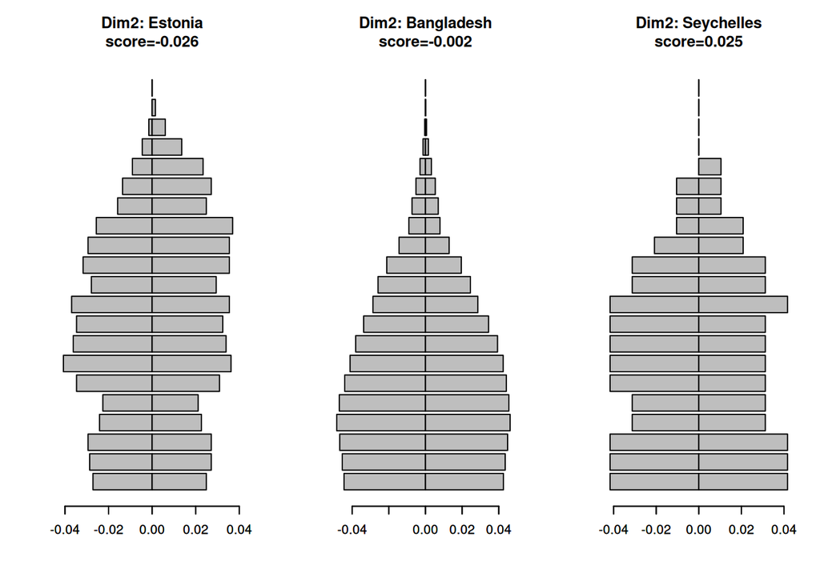

```r
# Dim 2
idx2 <- sapply(qs, function(q) closest_q(X[,2], q))

op <- par(mfrow=c(1,3))
for (j in idx2){
  plot.PopPyrISO(PopPyrISO[j, 6:47],
                 label=paste0("Dim2: ", PopPyrISO$English.short.name[j],
                              "\nscore=", round(X[j,2], 3)))
}
```

```r
par(op)
```

The table below summarizes the countries and their respective MDS scores at each quantile.

```r
data.frame(
  Dim = c(rep("Dim1",3), rep("Dim2",3)),
  Quantile = rep(qs, 2),
  Country = PopPyrISO$English.short.name[c(idx1, idx2)],
  Score = c(X[idx1,1], X[idx2,2])
)
```

```
##    Dim Quantile                    Country        Score
## 1 Dim1      0.1 Taiwan (Province of China) -0.230685414
## 2 Dim1      0.5                    Morocco  0.000468016
## 3 Dim1      0.9              Guinea-Bissau  0.230220507
## 4 Dim2      0.1                    Estonia -0.026260394
## 5 Dim2      0.5                 Bangladesh -0.001610741
## 6 Dim2      0.9                 Seychelles  0.025477879
```

Dimension 1 captures the dominant variation in the population pyramids. Moving from the 0.1 to the 0.9 quantile, the average shape shifts from a relatively “top-heavy / narrow-base” profile to a much more “bottom-heavy / wide-base” profile (Taiwan → Morocco → Guinea-Bissau). Hence, MDS1 can be interpreted as the main age-structure gradient in the data.

Dimension 2 captures a secondary shape contrast that is not explained by MDS1. Comparing the 0.1 and 0.9 quantile pyramids (Estonia → Bangladesh → Seychelles), the main differences are concentrated in specific age ranges (mid/older-age tail and/or the upper-age balance), while the global pattern captured by MDS1 is less affected. Therefore, MDS2 represents a second-order adjustment in pyramid shape (a finer redistribution across age groups).

### 2e. Fitted distances

To assess the goodness of fit of the 2D MDS solution, we compare the fitted distances (the Euclidean distances between points on the 2D map) against the original observed distances (the original dissimilarity matrix).

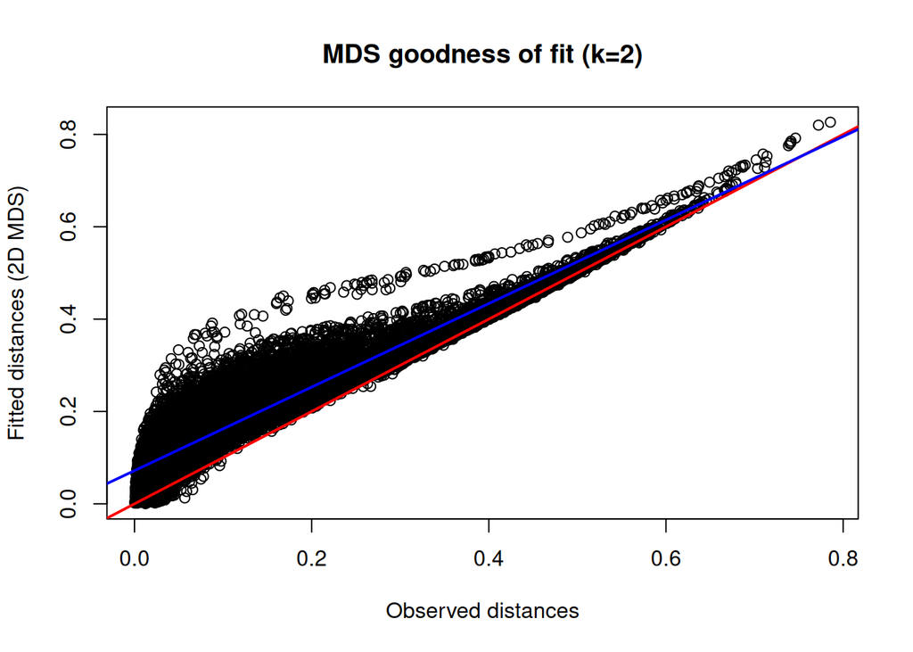

```r
d_fit <- dist(out$points[, 1:2])

# Scatter plot: observed vs fitted
plot(as.dist(d.KL), d_fit,
     xlab = "Observed distances",
     ylab = "Fitted distances (2D MDS)",
     main = "MDS goodness of fit (k=2)")

abline(0, 1, col = "red", lwd = 2)

fit_lm <- lm(d_fit ~ as.dist(d.KL))
abline(fit_lm, col = "blue", lwd = 2)
```

```r
R2 <- summary(fit_lm)$r.squared
R2
```

```
## [1] 0.8958815
```

The linear regression yields $R^2 = 0.896$. This value represents the proportion of variance in the observed distances that is successfully explained by the 2D MDS configuration. Thus, the model preserves most of the original dissimilarities - although some distortion remains (as seen by the spread around $y=x$).

### 2f. Non-metric MDS

We now perform a non-metric MDS using the isoMDS algorithm, which focuses on preserving the rank order of dissimilarities. We use the classical MDS (cmdscale) coordinates as an initial configuration, and the algorithm iteratively adjusts the coordinates of each country to minimise the stress function.

```r
library(MASS)
out.iso <- isoMDS(d.KL, k = 2)
```

The algorithm converged to a final stress value of approximately $4.35%$. This value is considered an excellent fit of the data to the 2D representation.

We plot the 2D solution, labelling with 3-codes for visibility.

```r
X_iso <- out.iso$points

rx <- range(X_iso[,1]); ry <- range(X_iso[,2])
padx <- 0.10 * diff(rx)
pady <- 0.10 * diff(ry)
```

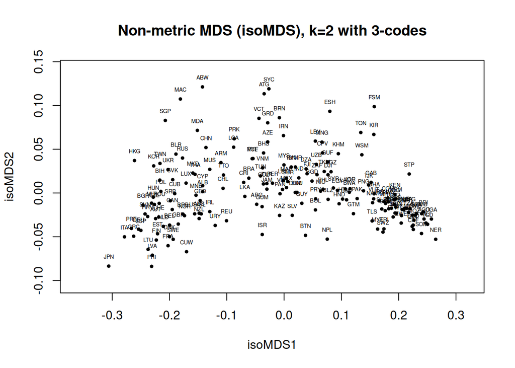

```r
plot(X_iso[,1], X_iso[,2],
     pch = 19, cex = 0.5,
     xlab = "isoMDS1", ylab = "isoMDS2",
     main = "Non-metric MDS (isoMDS), k=2 with 3-codes",
     xlim = c(rx[1]-padx, rx[2]+padx),
     ylim = c(ry[1]-pady, ry[2]+pady))

par(xpd = NA)
text(X_iso[,1], X_iso[,2],
     labels = PopPyrISO$Alpha.3.code,
     cex = 0.45, pos = 3)
```

```r
par(xpd = FALSE)
```

Despite the fact that countries in the Non-metric plot appear more spread apart, the relative positions of countries remain similar in both Classical and Non-metric. This consistency confirms that the demographic patters in the data are robust and well-represented in two dimensions.

### 2g. Interpretation

Following 2.d, we interpret each isoMDS dimension using the 0.1/0.5/0.9 quantile prototypes and compare them with classical MDS.

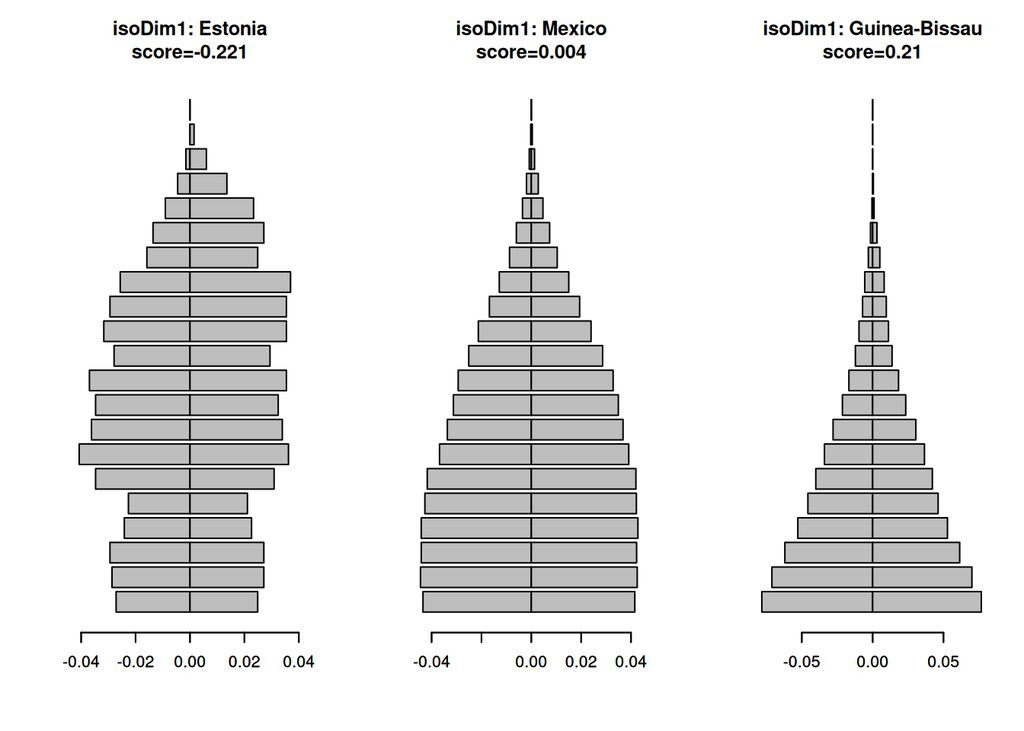

```r
# Dim 1 (isoMDS)
idx1_iso <- sapply(qs, function(q) closest_q(X_iso[,1], q))
op <- par(mfrow=c(1,3))
for (j in idx1_iso){
  plot.PopPyrISO(PopPyrISO[j, 6:47],
                 label=paste0("isoDim1: ", PopPyrISO$English.short.name[j],
                              "\nscore=", round(X_iso[j,1], 3)))
}
```

```r
par(op)
```

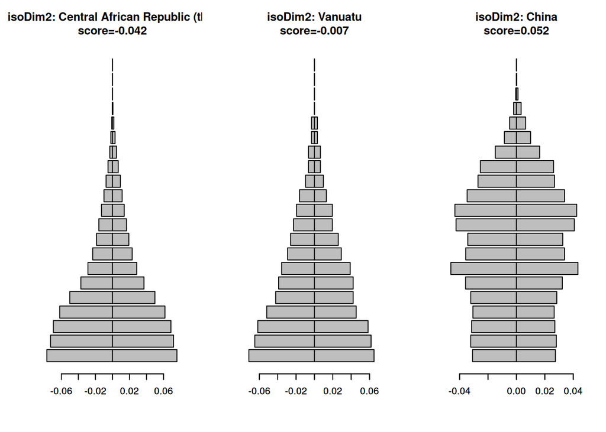

```r
# Dim 2 (isoMDS)
idx2_iso <- sapply(qs, function(q) closest_q(X_iso[,2], q))
op <- par(mfrow=c(1,3))
for (j in idx2_iso){
  plot.PopPyrISO(PopPyrISO[j, 6:47],
                 label=paste0("isoDim2: ", PopPyrISO$English.short.name[j],
                              "\nscore=", round(X_iso[j,2], 3)))
}
```

```r
par(op)
```

```r
data.frame(
  Dim = c(rep("Dim1",3), rep("Dim2",3)),
  Quantile = rep(qs, 2),
  Country = PopPyrISO$English.short.name[c(idx1_iso, idx2_iso)],
  Score = c(X_iso[idx1_iso,1], X_iso[idx2_iso,2])
)
```

```
##    Dim Quantile                        Country        Score
## 1 Dim1      0.1                        Estonia -0.220779133
## 2 Dim1      0.5                         Mexico  0.004220753
## 3 Dim1      0.9                  Guinea-Bissau  0.210360817
## 4 Dim2      0.1 Central African Republic (the) -0.041663918
## 5 Dim2      0.5                        Vanuatu -0.006700299
## 6 Dim2      0.9                          China  0.051946007
```

```r
round(cor(cbind(X[,1:2], X_iso[,1:2])), 2)
```

```
##       [,1]  [,2]  [,3]  [,4]
## [1,]  1.00  0.00  0.98 -0.02
## [2,]  0.00  1.00 -0.01  0.72
## [3,]  0.98 -0.01  1.00 -0.02
## [4,] -0.02  0.72 -0.02  1.00
```

The isoMDS dimensions lead to the same qualitative interpretation as classical MDS: isoMDS1 matches the main age-structure gradient, while isoMDS2 captures a secondary shape contrast. This agreement is also supported numerically by the correlations between coordinates: cor(MDS1, isoMDS1) ≈ 0.98 and cor(MDS2, isoMDS2) ≈ 0.72, with negligible cross-correlations. Differences are expected because isoMDS optimizes the fit to the *rank order* of dissimilarities (non-metric objective), and MDS coordinates are only identified up to sign/rotation.

### 2h. Stress

We compute the stress for a 1, 2, 3, 4, 5 and 6 dimensional solution, then plot stress as a function of the dimension.

```r
K <- 6
stress <- numeric(K)

for (k in 1:K) {
  stress[k] <- isoMDS(as.dist(d.KL), k = k, maxit = 200)$stress
}
```

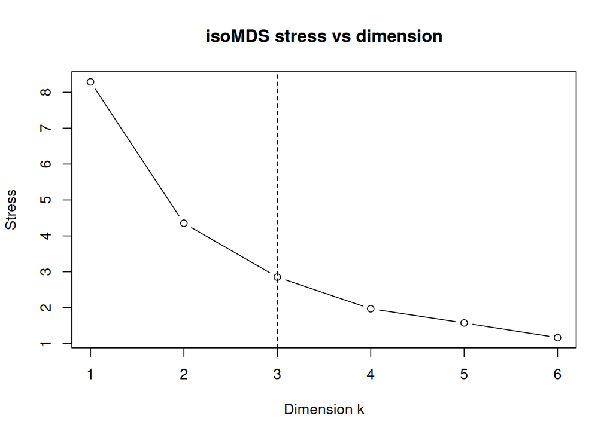

```r
plot(1:K, stress, type = "b",
     xlab = "Dimension k",
     ylab = "Stress",
     main = "isoMDS stress vs dimension")
abline(v=3, lty=2)
```

Stress decreases sharply from $k=1$ to $k=3$ and then levels off. Thus, we can conclude that $k=3$ dimensions are sufficient for a good fit ($k=4$ would only provide a moderate additional improvement).

## 3. Plotting a map with scores from PCA or MDS

### 3a. PCA world map

In this section, we divide the countries into 4 groups according to their scores in the 1st PC, cutting them by the quartiles Q1, Q2 and Q3 (use the function cut). Then, we plot the world map using different colors for countries belonging to different groups. We use the following function:

```r
plot_world <- function(Group_Indicator,
                       ISO.3.code=PopPyrISO$Alpha.3.code){
  library(maps)
  # Country names in the data base 'world',
  # from library maps, of each country in
  # the data.frame
  country.names.world <- iso.expand(ISO.3.code)
  # assigning polygons in "world" to each country
  country.to.map <- match.map("world",country.names.world)

  ncolors <- length(unique(Group_Indicator))
  x <- Group_Indicator[country.to.map]
  # with a color palette
  #color <- terrain.colors(n=ncolors)
  color <- palette.colors(n = ncolors,
                          palette = "pastel 1")
  map("world", fill = TRUE, col = color[x])
  map("world", add = TRUE) # plot again borders
  legend("bottomleft",paste("Group",1:ncolors),
         fill=color[1:ncolors],cex=1,
         border=0,bty="o",box.col=0)
}
```

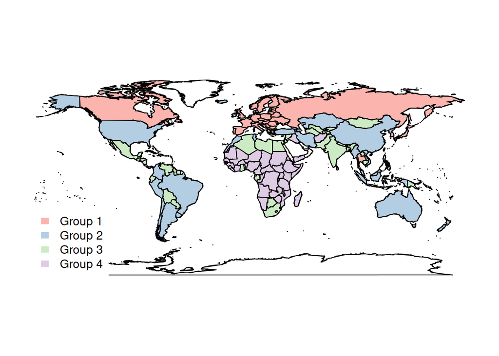

```r
# 1st PCA dimension
pca1 <- PCA$scores[,1]

# quartiles
Q <- quantile(pca1, probs = c(0.25, 0.50, 0.75), na.rm = TRUE)

# 4 groups (1..4)
Group_Indicator <- cut(pca1,
                       breaks = c(-Inf, Q[1], Q[2], Q[3], Inf),
                       labels = 1:4,
                       include.lowest = TRUE)

Group_Indicator <- as.numeric(as.character(Group_Indicator))

# plot map
plot_world(Group_Indicator, ISO.3.code = PopPyrISO$Alpha.3.code)
```

### 3b. MDS world map

Now, we repeat the same procedure, but divide the data according to their scores along the first dimension obtained from classical metric MDS.

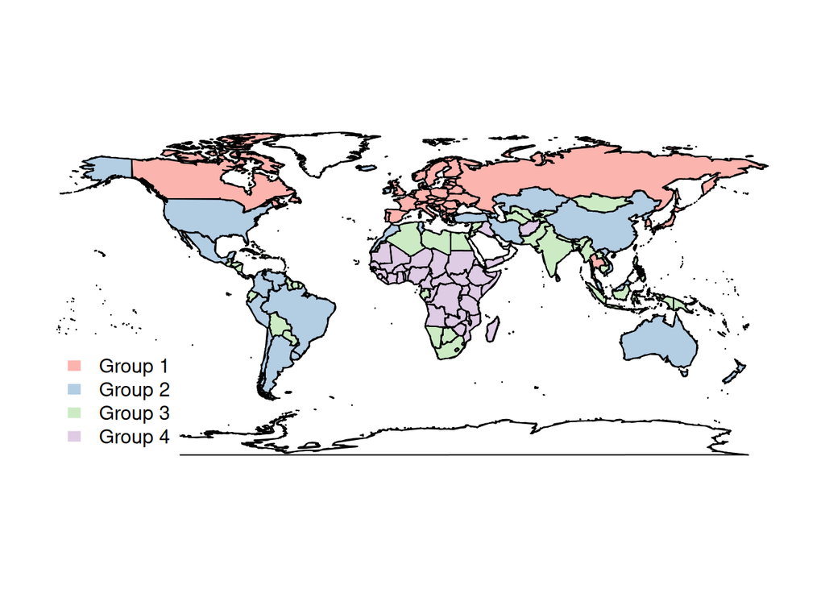

```r
# 1st MDS dimension
mds1 <- X[,1]

# quartiles
Q <- quantile(mds1, probs = c(0.25, 0.50, 0.75), na.rm = TRUE)

# 4 groups (1..4)
Group_Indicator <- cut(mds1,
                       breaks = c(-Inf, Q[1], Q[2], Q[3], Inf),
                       labels = 1:4,
                       include.lowest = TRUE)

Group_Indicator <- as.numeric(as.character(Group_Indicator))

# plot map
plot_world(Group_Indicator, ISO.3.code = PopPyrISO$Alpha.3.code)
```

### 3.c Interpretation

The colour code is the following:

Group 1 → lowest 25% PCA1 values → soft pink/red Group 2 → 25–50% PCA1 values → light blue Group 3 → 50–75% PCA1 values → pale green Group 4 → top 25% PCA1 values → lavender

Note that, since we only consider the scores on PC1, we group populations according to their position along the demographic aging axis. Group 1 corresponds to the oldest populations (i.e., those in the first quartile of the PC1 distribution). This group includes, for instance, European countries, as well as Korea, Japan, and Canada.

On the other hand, Group 4 corresponds to the youngest populations (e.g., many African countries).

Groups 2 and 3 cover the intermediate 50% of the distribution (i.e., the interquartile range), representing populations with a more balanced age structure — with Group 2 being relatively older and Group 3 relatively younger.

We observe that the plots obtained using PCA and MDS are very similar. Some countries fall into neighboring groups (e.g., Mexico and Venezuela), but the overall grouping structure is largely consistent across the two methods.